# Module 4: Extract and Analyze GIS Data

IALE 2015 R GIS Workshop

July 7, 2015

# Module 4.2

## Goals: Perform statistics on extracted point data

Learn how to analyze raster- and vector-based data, applying common and customized statistical analyses to single or multiple data layers.

## R Packages Needed

```r
library(sp)
library(rgdal)
library(raster)
library(fields)
```

## Set Your Working Directory

Change this to the correct path name on your machine

```r
setwd("~/Documents/IALE2015_StudentWorkshop/module4")
```

## Reload data

Only necessary if you closed R after the last section.

```r
extract_juos <- read.csv("data/outdata/extract_juos.csv")
topo.cp <- brick("data/outdata/topo_cp.grd")
soil.cp <- readOGR("data/outdata/soil", "soil")
```

Let’s make sure it’s a data frame type of object, and not something else.

```r
class(extract_juos)
```

```
## [1] "data.frame"
```

It’s also a good idea to look at the top and bottom of it.

```r
head(extract_juos)
```

```
##           X        Y juos elev       slp       asp point.ID poly.ID  mukey
## 1 -109.0390 40.99637    0   NA        NA        NA        1    1059 676954
## 2 -109.3372 40.95580    0 2415 3.2312350 214.86852        2     703 674453
## 3 -108.9809 40.95033    0 2455 0.9591002 107.85032        3    1059 676954
## 4 -109.4567 40.91271    1 1872 4.7746687  28.80268        4    1114 657964
## 5 -109.3977 40.91184    1 1989 6.0288043 180.73264        5     703 674453
## 6 -109.2789 40.91011    1 1737 0.8189415 247.79652        6     703 674453
##    taxorder taxsuborde   taxgrtgrou          taxsubgrp subord grtgrp
## 1 Mollisols    Cryolls  Argicryolls  Ustic Argicryolls    Cry    Arg
## 2 Aridisols    Calcids Haplocalcids Ustic Haplocalcids    Cal    Hap
## 3 Mollisols    Cryolls  Argicryolls  Ustic Argicryolls    Cry    Arg
## 4      <NA>       <NA>         <NA>               <NA>    non    non
## 5 Aridisols    Calcids Haplocalcids Ustic Haplocalcids    Cal    Hap
## 6 Aridisols    Calcids Haplocalcids Ustic Haplocalcids    Cal    Hap
##   c_order c_sbord c_ggrp phmin phave phmax frag3to10 sieveno4 sieveno10
```

[output cut: 34 more lines]

```r
tail(extract_juos)
```

```
##              X        Y juos elev         slp       asp point.ID poly.ID
## 1793 -112.6178 36.40603    0 1064 10.80322933 292.33603     1793     133
## 1794 -113.2308 36.39616    1 1966  1.70573187 321.25903     1794     125
## 1795 -107.5649 36.38947    0 2079  2.94599581  33.43987     1795     371
## 1796 -107.3978 36.39295    0 2002  0.40545148 318.09406     1796     387
## 1797 -107.5078 36.34562    0 1991  0.07966151 119.05460     1797     372
## 1798 -107.6191 36.34323    0 2109  2.69600415  11.24548     1798     371
##       mukey  taxorder taxsuborde    taxgrtgrou           taxsubgrp subord
## 1793 658396      <NA>       <NA>          <NA>                <NA>    non
## 1794 658428 Mollisols    Ustolls   Argiustolls  Aridic Argiustolls    Ust
## 1795 665839      <NA>       <NA>          <NA>                <NA>    non
## 1796 665856  Entisols   Orthents   Ustorthents   Typic Ustorthents    Ort
## 1797 665850  Entisols   Fluvents Torrifluvents Ustic Torrifluvents    Flu
## 1798 665839      <NA>       <NA>          <NA>                <NA>    non
##      grtgrp c_order c_sbord c_ggrp phmin phave phmax frag3to10 sieveno4
```

[output cut: 34 more lines]

## Raster Statistics

### Compare Rasters

Let’s confirm that our `RasterBrick` has 3 layers and that everything looks right.

```r
topo.cp
```

```
## class       : RasterBrick
## dimensions  : 578, 801, 462978, 3  (nrow, ncol, ncell, nlayers)
## resolution  : 0.008333333, 0.008333333  (x, y)
## extent      : -113.5992, -106.9242, 36.18774, 41.00441  (xmin, xmax, ymin, ymax)
## coord. ref. : +proj=longlat +datum=WGS84 +no_defs +ellps=WGS84 +towgs84=0,0,0
## data source : /Users/kjj/Documents/IALE2015_StudentWorkshop/module4/data/outdata/topo_cp.grd
## names       :       elev,        slp,        asp
## min values  :        725,          0,         -1
## max values  : 4138.00000,   26.42785,  359.95435
```

Let’s also note that you can access rasters in the brick using the $ symbol, like for columns in data frames and items in lists.

```r
topo.cp$elev
```

```
## class       : RasterLayer
## band        : 1  (of  3  bands)
## dimensions  : 578, 801, 462978  (nrow, ncol, ncell)
## resolution  : 0.008333333, 0.008333333  (x, y)
## extent      : -113.5992, -106.9242, 36.18774, 41.00441  (xmin, xmax, ymin, ymax)
## coord. ref. : +proj=longlat +datum=WGS84 +no_defs +ellps=WGS84 +towgs84=0,0,0
## data source : /Users/kjj/Documents/IALE2015_StudentWorkshop/module4/data/outdata/topo_cp.grd
## names       : elev
## values      : 725, 4138  (min, max)
```

A quick and easy way to see the distribution of values in the rasters and comparing them to each other is the `pairs` function.

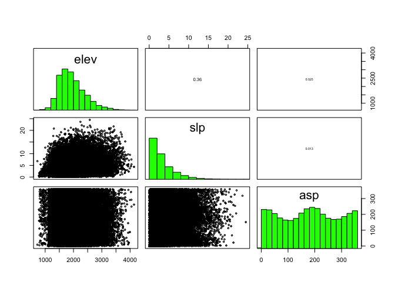

```r
pairs(topo.cp)
```

```r
?pairs
```

```
## Help on topic 'pairs' was found in the following packages:
##
##   Package               Library
##   graphics              /Library/Frameworks/R.framework/Versions/3.2/Resources/library
##   raster                /Library/Frameworks/R.framework/Versions/3.2/Resources/library
##
##
## Using the first match ...
```

So how does R know which `pairs` function to use? It all depends on which class the object is. The `raster` version of it will only be applied if it’s a `Raster*` object.

```r
class(topo.cp)
```

```
## [1] "RasterBrick"
## attr(,"package")
## [1] "raster"
```

## Summary Statistics on Rasters

You can calculate statistics on z values for the rasters in a `Raster*` object. For example, the mean and standard deviation:

```r
cellStats(topo.cp, stat="mean")
```

```
##        elev         slp         asp
## 1953.052627    3.295873  178.646871
```

```r
cellStats(topo.cp, stat="sd")
```

```
##       elev        slp        asp
## 452.051853   2.916307 104.898183
```

Generally there are multiple ways to do just about everything in R. The methods above are built into the raster package, and the actual computing is probably happening in efficient C code behind the scenes. So these are good for large rasters. However, if your rasters are a more manageable size, like the ones we have now, I prefer to use an alternative that is very flexible.

```r
summary(topo.cp[])
```

```
##       elev             slp              asp
##  Min.   : 725     Min.   : 0.00    Min.   : -1.00
##  1st Qu.:1619     1st Qu.: 1.22    1st Qu.: 86.75
##  Median :1881     Median : 2.32    Median :180.95
##  Mean   :1953     Mean   : 3.30    Mean   :178.65
##  3rd Qu.:2212     3rd Qu.: 4.47    3rd Qu.:266.43
##  Max.   :4138     Max.   :26.43    Max.   :359.95
##  NA's   :193591   NA's   :193591   NA's   :193591
```

```r
summary(topo.cp$elev[])
```

```
##    Min. 1st Qu.  Median    Mean 3rd Qu.    Max.    NA's
##     725    1619    1881    1953    2212    4138  193591
```

Then you can do what you want with the values. Many of these functions require you to use the `na.rm = TRUE` argument so that `NA`s aren’t included in the calculation. Here is the mean of elevation.

```r
mean(topo.cp$elev[], na.rm=T)
```

```
## [1] 1953.053
```

Here’s how you’d get the mean of all three layers.

```r
summary(colMeans(topo.cp[], na.rm=T))
```

```
##     Min.  1st Qu.   Median     Mean  3rd Qu.     Max.
##    3.296   90.970  178.600  711.700 1066.000 1953.000
```

## Transformations of Raster Data

You can transform the raster values. For example, take the log of the elevation values.

```r
summary(log(topo.cp$elev[]))
```

```
##    Min. 1st Qu.  Median    Mean 3rd Qu.    Max.    NA's
##    6.59    7.39    7.54    7.55    7.70    8.33  193591
```

`raster` package will even know what to do if you apply operations to the raster object. It will let you do this to the raster object itself. Let’s make a new object to hold our log-transformed elevation data.

```r
elev.log <- log(topo.cp$elev)
```

You could also scale the values from 0 to 1. We’ll do that with slope.

```r
slp.scale <- topo.cp$slp/max(topo.cp$slp[], na.rm=T)
```

You can analyze the transformed data as you like.

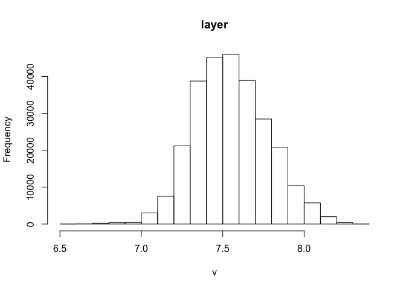

```r
hist(elev.log)
```

```r
summary(elev.log)
```

```
##                layer
## Min.    6.586172e+00
## 1st Qu. 7.389564e+00
## Median  7.539559e+00
## 3rd Qu. 7.701652e+00
## Max.    8.327968e+00
## NA's    1.935910e+05
```

You might want to add a transformed raster into your RasterBrick as an extra layer.

```r
topo.cp$elev.log <- elev.log
```

Alternatively, you might want to substitute one of your `RasterBrick` layers with transformed values.

```r
topo.cp$slp[] <- slp.scale[]
```

## Model Selection

What is powerful about R is that you can take tabular data extracted from rasters and vectors and you can analyze it with some of the best statistical tools available. One common approach to studying landscape ecology is model selection. Here is a simple example of model selection.

The basic approach is to decide *a priori* which combinations of covariates are reasonable hypotheses. After carefully considering all you know about the biology of the organism, you may be able to develop a series of several combinations of covariates that could explain the data.  
# Note: these particular models are not derived by an expert - just Karl’s guesses for the purpose of demonstration!

First run models on the combinations of covariates of interest. These are run specifically on our `extract_juos` object with raster and vector data extracted into it. The models we’re using here are simple linear models, but there any number of other models to use.

```r
elev.lm <- lm(elev ~ juos, data=extract_juos)
asp.lm <- lm(asp ~ juos, data=extract_juos)
elev.slp.asp.lm <- lm(elev + slp + asp ~ juos, data=extract_juos)
elev.clay.lm <- lm(elev + clay ~ juos, data=extract_juos)
```

By running AIC on these models, we can compare support in the data for each one. The one with the **lowest** score is the best of the set that you tested.

```r
AIC(elev.lm)
```

```
## [1] 26868.9
```

```r
AIC(asp.lm)
```

```
## [1] 21792.59
```

```r
AIC(elev.slp.asp.lm)
```

```
## [1] 26958.01
```

```r
AIC(elev.clay.lm)
```

```
## [1] 26878.58
```

So aspect appears to be the best fit of these 4 options.

## Interpolate Values Between Points

### Thin plate spline regression

There are at least dozens of ways to interpolate values between points in R. This particular one is fairly simple. It fits a model across irregularly spaced points. The `Tps` function is from a package you haven’t used yet called `fields`.

```r
juos.tps <- Tps(extract_juos[,1:2], extract_juos$juos)
```

The raster package has an `interpolate` function that will let you take a `Tps` object and interpolate probabilities of juniper occurrence based on presence/absence data. It requires an existing `raster` object that it will fill with new values, so first we create it from a layer, like elevation.

```r
juos.int <- interpolate(topo.cp$elev, juos.tps)
```

This creates a square raster.

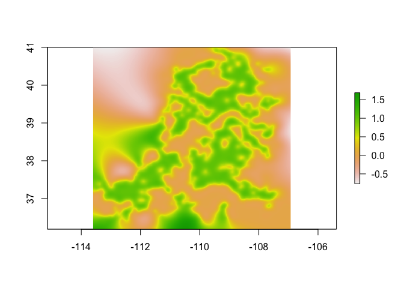

```r
plot(juos.int)
```

So let’s mask that to the Colorado Plateau perimeter.

```r
juos.int <- mask(juos.int, topo.cp$elev)
```

Plot the masked result

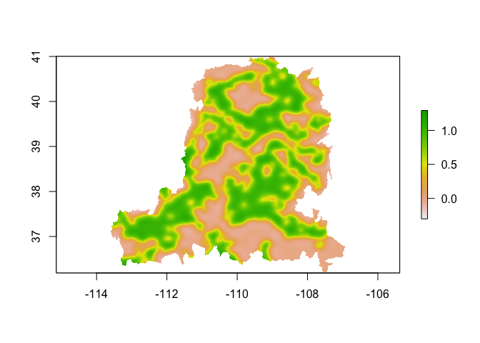

```r
plot(juos.int)
```

Write the result to file

```r
writeRaster(juos.int, "data/outdata/juos_interpolation.tif", overwrite=T)
```

You can also save it as a `.pdf`, `.png`, or other graphics file type. The first call opens up a new file with the desired name.

```r
pdf("data/outdata/juos_interpolation.pdf")
```

The next call fills that file with the data it needs.

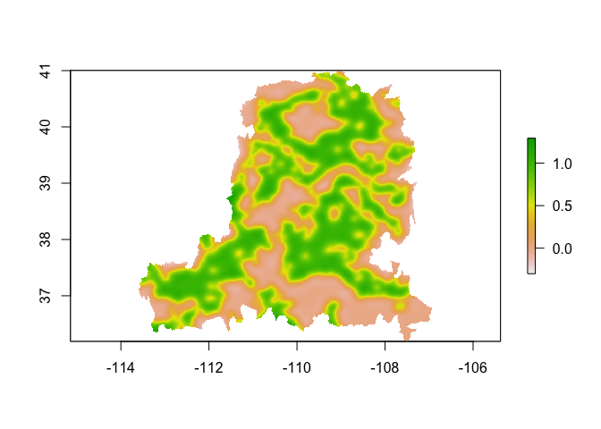

```r
plot(juos.int)
```

This call closes up the file so that if you plot anything else, it won’t get added to.

```r
dev.off()
```